# Example analysis

GB

2022-06-14

We tested this by asking subjects to rate music that varied in complexity (quantified here as (pulse) entropy) in terms of how much they wanted to move … We wanted to test whether subjects’ ratings would be higher when they actively tapped along to the music compared to when they passively listened to it, particularly at moderate levels of rhythmic complexity.

```r
library(readr)
library(dplyr)
library(zoo)
library(ggplot2)
library(ez)
library(tidyr)
library(lme4)
library(lmerTest)
library(effects)
```

Here is a look at the raw data

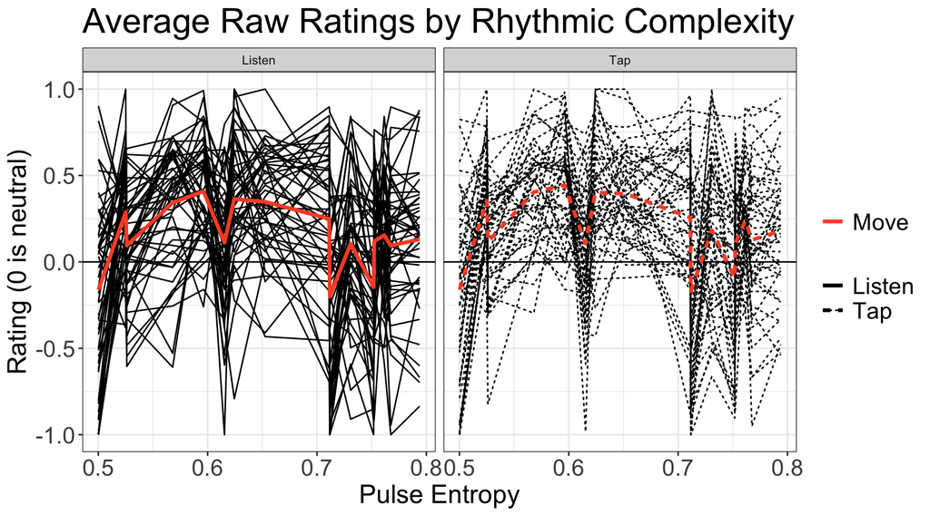

# Original analysis

The standard analysis fits different models and continues with model selection:

```r
# null/empty/intercepts-only model
m0 <- lmer(AvgMove~1+(1|Subject), data=BehSub)
# effect of tapping vs. listening condition
mt <- lmer(AvgMove~1+Condition+(1|Subject), data=BehSub)
 # add linear effect of rhythmic complexity
ml <- lmer(AvgMove~1+Entropy*Condition+(1+Entropy|Subject), data=BehSub)
# add quadratic effects of rhythmic complexity
mq <- lmer(AvgMove~1+Condition*poly(Entropy,2)+(1+poly(Entropy,2)|Subject), data=BehSub)
anova(m0,mt,ml,mq) # quadratic model is the best fit, yippee!
```

```
## refitting model(s) with ML (instead of REML)
```

```
## Data: BehSub
## Models:
## m0: AvgMove ~ 1 + (1 | Subject)
## mt: AvgMove ~ 1 + Condition + (1 | Subject)
## ml: AvgMove ~ 1 + Entropy * Condition + (1 + Entropy | Subject)
## mq: AvgMove ~ 1 + Condition * poly(Entropy, 2) + (1 + poly(Entropy, 2) | Subject)
##    npar    AIC    BIC  logLik deviance   Chisq Df Pr(>Chisq)
## m0    3 1380.6 1396.7 -687.32   1374.6
## mt    4 1378.6 1400.0 -685.31   1370.6  4.0125  1    0.04516 *
## ml    8 1342.0 1384.8 -663.00   1326.0 44.6260  4  4.755e-09 ***
## mq   13 1252.8 1322.4 -613.41   1226.8 99.1846  5  < 2.2e-16 ***
## ---
## Signif. codes:  0 '***' 0.001 '**' 0.01 '*' 0.05 '.' 0.1 ' ' 1
```

```r
summary(mq)
```

```
## Linear mixed model fit by REML. t-tests use Satterthwaite's method [
## lmerModLmerTest]
## Formula: AvgMove ~ 1 + Condition * poly(Entropy, 2) + (1 + poly(Entropy,
##     2) | Subject)
##    Data: BehSub
##
## REML criterion at convergence: 1235.9
##
## Scaled residuals:
##     Min      1Q  Median      3Q     Max
## -3.9701 -0.4679  0.1293  0.6053  3.3478
##
## Random effects:
##  Groups   Name              Variance Std.Dev. Corr
##  Subject  (Intercept)       0.04118  0.2029
##           poly(Entropy, 2)1 9.02640  3.0044   0.49
##           poly(Entropy, 2)2 2.85737  1.6904   0.70 0.97
##  Residual                   0.11552  0.3399
## Number of obs: 1566, groups:  Subject, 49
##
## Fixed effects:
##                                  Estimate Std. Error         df t value
## (Intercept)                       0.14391    0.03143   56.05684   4.579
## ConditionTap                      0.03659    0.01718 1464.01165   2.130
## poly(Entropy, 2)1                -1.49200    0.64441   93.69986  -2.315
## poly(Entropy, 2)2                -3.12462    0.53793  191.36116  -5.809
## ConditionTap:poly(Entropy, 2)1    0.19065    0.67978 1464.01164   0.280
## ConditionTap:poly(Entropy, 2)2    0.06143    0.67978 1464.01165   0.090
##                                Pr(>|t|)
## (Intercept)                    2.65e-05 ***
## ConditionTap                     0.0334 *
## poly(Entropy, 2)1                0.0228 *
## poly(Entropy, 2)2              2.59e-08 ***
## ConditionTap:poly(Entropy, 2)1   0.7792
## ConditionTap:poly(Entropy, 2)2   0.9280
## ---
## Signif. codes:  0 '***' 0.001 '**' 0.01 '*' 0.05 '.' 0.1 ' ' 1
##
## Correlation of Fixed Effects:
##             (Intr) CndtnT p(E,2)1 p(E,2)2 CT:(E,2)1
## ConditionTp -0.273
## ply(Ent,2)1  0.303  0.000
## ply(Ent,2)2  0.290  0.000  0.289
## CndT:(E,2)1  0.000  0.000 -0.527   0.000
## CndT:(E,2)2  0.000  0.000  0.000  -0.632   0.000
```

Connor: “As predicted, there is a significant negative quadratic trend for rhythmic complexity indicating an inverted U-shaped curve”.

# Original analysis, but Bayesian

We can do the same in using Bayesian estimation and `rstanarm`:

```r
library(rstanarm)
options(mc.cores = 4)
m0 <- stan_lmer(AvgMove~1+(1|Subject), data=BehSub)
  # effect of tapping vs. listening condition
  mt <- stan_lmer(AvgMove~1+Condition+(1|Subject), data=BehSub)
  # add linear effect of rhythmic complexity
  ml <- stan_lmer(AvgMove~1+Entropy*Condition+(1+Entropy|Subject), data=BehSub)
  # add quadratic effects of rhythmic complexity
  mq <- stan_lmer(AvgMove~1+Condition*poly(Entropy,2)+(1+poly(Entropy,2)|Subject), data=BehSub)
```

Next we calculate loo values:

```r
m0_loo = loo(m0)
mt_loo = loo(mt)
ml_loo = loo(ml)
mq_loo = loo(mq)
```

and we compare the models:

```r
loo_compare(m0_loo,mt_loo,ml_loo,mq_loo)
```

```
##    elpd_diff se_diff
## mq   0.0       0.0
## ml -52.6      11.4
## mt -74.8      11.8
## m0 -76.2      11.9
```

Also here the quadratic model is clearly the best model.

But lets quickly look at posterior predictions:

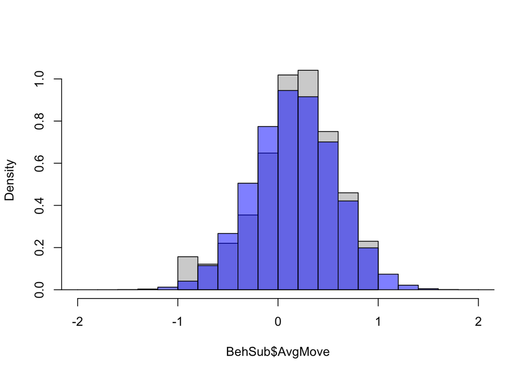

```r
hist(BehSub$AvgMove, probability = TRUE, main = "", xlim = c(-2,2))
posterior_predict(mq) %>% hist(probability = TRUE, col = adjustcolor("blue",alpha = .5), add = T)
```

The linear model does not seem to capture the data well.

# A better Bayesian analysis

As always, I’ll try it with a an ordinal regression / IRT model. Remember that only because we use a slider scale to capture responses, this does not mean that we are really measuring things on a cardinal scale.

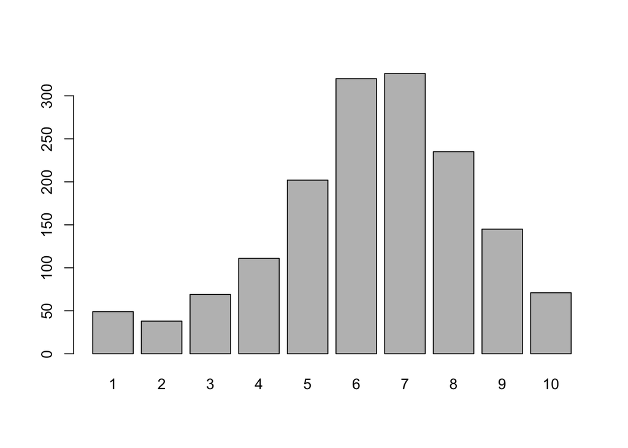

```r
BehSub$AvgMove.c =
  as.numeric(
    cut(BehSub$AvgMove,
        breaks = seq(-1.001,1.001, length.out = 11)))
table(BehSub$AvgMove.c) %>% barplot()
```

And now we use brms to estimate an ordinal regression with subject random effects (I don’t think we need random slopes here).

```r
library(brms)
# model formula
f = AvgMove.c ~ s(Entropy, by = Condition) + Condition + (1 | Subject)
# make stan-data to get info for prior specification
standata = make_standata(f,family = cumulative(link = "probit"),data = BehSub)
# initialize parameters
my.inits = lapply(1:4, function(x) {
    list(
      intercept = seq(-2,2,length.out = standata$nthres),
      bs = rnorm(standata$Ks,0,.05),
      zs_1_1 = rnorm(standata$knots_1[1],0,.05),
      sd_1 = runif(standata$M_1,.01,.1)
    )
  })

# fit model
sf = brm(f,
         data = BehSub,
         backend = "cmdstanr",
         prior = my.prior,
         family = cumulative(link = "probit"), # logitic regression with logit link
         inits = my.inits)
```

Did the model converge?

```r
summary(sf)
```

```
##  Family: cumulative
##   Links: mu = probit; disc = identity
## Formula: AvgMove.c ~ s(Entropy, by = Condition) + Condition + (1 | Subject)
##    Data: BehSub (Number of observations: 1566)
##   Draws: 4 chains, each with iter = 2000; warmup = 1000; thin = 1;
##          total post-warmup draws = 4000
##
## Smooth Terms:
##                                Estimate Est.Error l-95% CI u-95% CI Rhat
## sds(sEntropyConditionListen_1)     1.16      0.48     0.51     2.27 1.00
## sds(sEntropyConditionTap_1)        1.40      0.56     0.63     2.80 1.00
##                                Bulk_ESS Tail_ESS
## sds(sEntropyConditionListen_1)      966     1496
## sds(sEntropyConditionTap_1)         824     1617
##
## Group-Level Effects:
## ~Subject (Number of levels: 49)
##               Estimate Est.Error l-95% CI u-95% CI Rhat Bulk_ESS Tail_ESS
## sd(Intercept)     0.67      0.07     0.54     0.84 1.01      707     1395
##
## Population-Level Effects:
##                            Estimate Est.Error l-95% CI u-95% CI Rhat Bulk_ESS
## Intercept[1]                  -2.25      0.13    -2.49    -2.00 1.01      500
## Intercept[2]                  -1.93      0.12    -2.16    -1.69 1.01      457
## Intercept[3]                  -1.55      0.11    -1.78    -1.34 1.01      435
## Intercept[4]                  -1.15      0.11    -1.37    -0.93 1.01      419
## Intercept[5]                  -0.63      0.11    -0.84    -0.41 1.01      412
## Intercept[6]                   0.06      0.11    -0.14     0.28 1.01      403
## Intercept[7]                   0.78      0.11     0.57     0.99 1.01      404
## Intercept[8]                   1.45      0.11     1.24     1.67 1.01      437
## Intercept[9]                   2.21      0.12     1.98     2.44 1.00      470
## ConditionTap                   0.11      0.05     0.01     0.21 1.00     4295
## sEntropy:ConditionListen_1     3.13      0.83     1.55     4.81 1.00     1850
## sEntropy:ConditionTap_1        3.56      0.85     1.94     5.23 1.00     2197
##                            Tail_ESS
## Intercept[1]                   1065
## Intercept[2]                   1077
## Intercept[3]                   1026
## Intercept[4]                    884
## Intercept[5]                    931
## Intercept[6]                    938
## Intercept[7]                    872
## Intercept[8]                    875
## Intercept[9]                   1033
## ConditionTap                   2454
## sEntropy:ConditionListen_1     2160
## sEntropy:ConditionTap_1        2801
##
## Family Specific Parameters:
##      Estimate Est.Error l-95% CI u-95% CI Rhat Bulk_ESS Tail_ESS
## disc     1.00      0.00     1.00     1.00   NA       NA       NA
##
## Draws were sampled using sample(hmc). For each parameter, Bulk_ESS
## and Tail_ESS are effective sample size measures, and Rhat is the potential
## scale reduction factor on split chains (at convergence, Rhat = 1).
```

To make posterior predictive plots, we first make posterior predictions:

```r
pp = posterior_epred(sf)
pred =
  apply(pp,1, function(x) {
    apply(x,1, function(z) sum(z*(1:10)))
  })
p = apply(pp,1,colMeans)
```

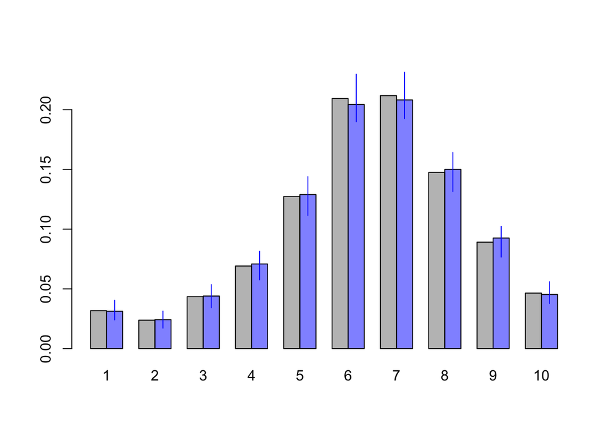

```r
CIs = apply(p,1,function(x) quantile(x,probs = c(.025,.975)))
clrs = c("grey75",adjustcolor("blue",alpha = .5))
h =
  rbind(rowMeans(p),
        prop.table(table(BehSub$AvgMove.c))) %>%
  barplot(beside = TRUE, ylim = c(0,max(CIs)), col = clrs)
arrows(x0 = h[2,], y0 = CIs[1,], y1 = CIs[2,], length = 0, col = "blue")
```

This looks better than the other plot.

Now lets look at the predicted move ratings:

```r
qs = quantile(BehSub$Entropy,c(.25,.75))
p = conditional_effects(sf,"Entropy:Condition")[[1]]
```

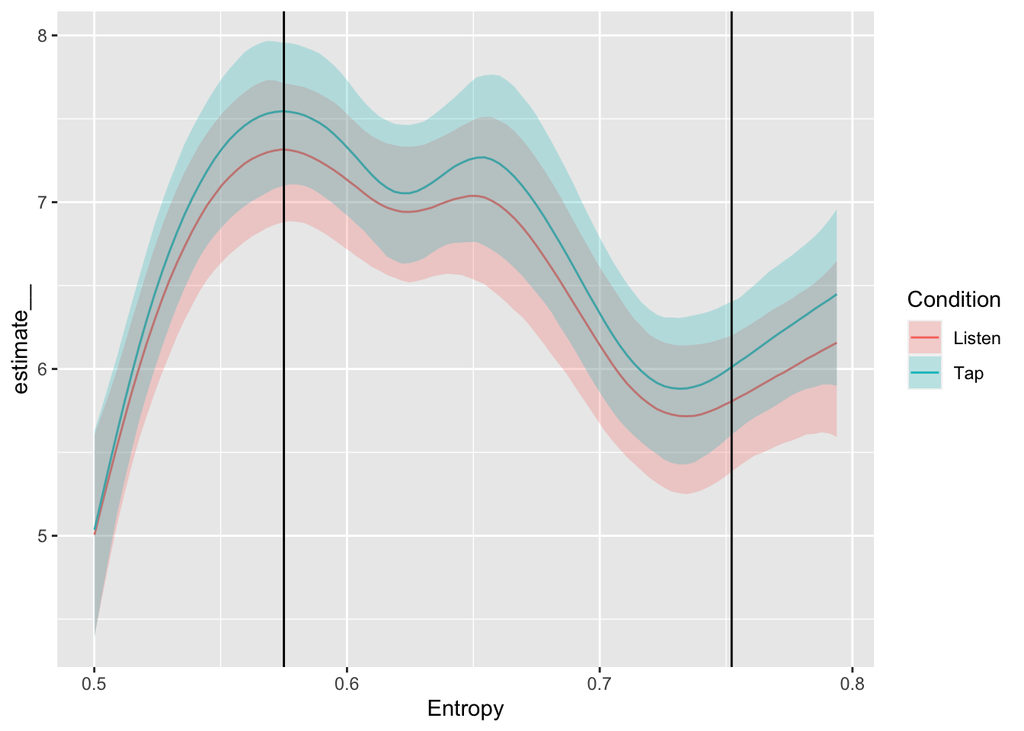

```r
p1 =
  p %>%
  ggplot(aes(x = Entropy, y = estimate__, color = Condition, fill = Condition)) +
  geom_line() +
  geom_ribbon(aes(ymin = lower__, ymax = upper__), alpha = .25, color = NA) +
  geom_vline(xintercept = qs)
p1
```

We clearly see an inverted-U shape here.

Instead of comparing this with an alternative model that does not use splines, well compare ratings at the high and low entries with those at medium entropy:

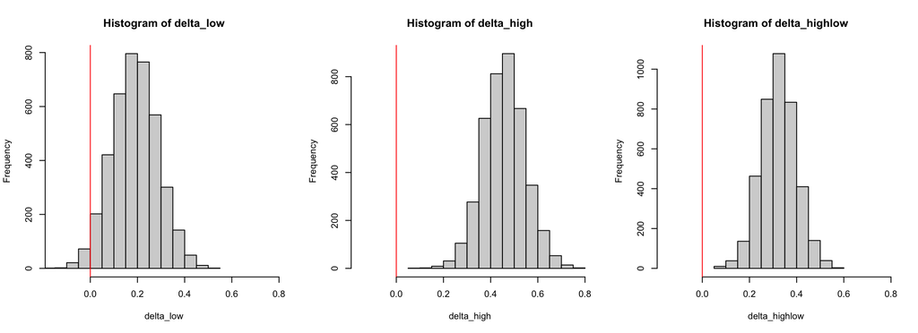

```r
move.low_e =
  posterior_epred(
    sf,
    newdata = BehSub[BehSub$Entropy <= qs[1],]) %>%
  apply(1,colMeans) %>%
  apply(2, function(x) sum(x*(1:10)))

move.medium_e =
  posterior_epred(
    sf,
    newdata = BehSub[BehSub$Entropy > qs[1] & BehSub$Entropy <= qs[2],]) %>%
  apply(1,colMeans) %>%
  apply(2, function(x) sum(x*(1:10)))

move.high_e =
  posterior_epred(
    sf,
    newdata = BehSub[BehSub$Entropy > qs[2],]) %>%
  apply(1,colMeans) %>%
  apply(2, function(x) sum(x*(1:10)))

par(mfrow = c(1,3))
delta_high = move.medium_e-move.high_e
delta_low = move.medium_e-move.low_e
delta_highlow = move.medium_e-(move.low_e+move.high_e)/2
xlim = range(c(delta_high,delta_highlow,delta_low))
hist(delta_low, xlim = xlim); abline(v = 0, col = "red")
hist(delta_high, xlim = xlim); abline(v = 0, col = "red")
hist(delta_highlow, xlim = xlim); abline(v = 0, col = "red")
```

On average, participants move ratings are by 0.323259 (95% credible interval: 0.18, 0.47) higher at medium entropy than at high or low entropy.

One challenge here is to define medium entropy. One could e.g. use the slopes of the earlier figure to determine when the plateau is reached.